# Variables and block effect

Théo Guillerminet

25 Janvier 2022

```r
library(magrittr)
library(tidyr)
library(dplyr)
library(stringr)
library(ggplot2)
library(lme4)
library(lmerTest)
library(broom.mixed)
```

# 1 Initialisation and data import

```r
source("scripts/init.R")
source("scripts/import_data.R")

glimpse(data_phenot_parms_clean)
```

```
## Rows: 1,995
## Columns: 6
## $ robot_id    <chr> "R20-20210930-001", "R20-20210930-001", "R20-20210930-001"~
## $ strain_name <chr> "LB-PD7-T1-1", "LB-PD7-T1-1", "LB-PD7-T1-1", "LB-PD7-T1-1"~
## $ bloc        <fct> 3, 3, 3, 3, 3, 3, 3, 3, 3, 3, 3, 3, 3, 3, 3, 3, 3, 3, 3, 3~
## $ bloc_month  <fct> 1, 1, 1, 1, 1, 1, 1, 1, 1, 1, 1, 1, 1, 1, 1, 1, 1, 1, 1, 1~
## $ parameter   <chr> "cell_t0", "cell_t27", "co2max", "death_prct", "lag", "tvm~
## $ value       <dbl> 9.810000e+05, 7.640000e+07, 2.223684e+01, 1.330000e+01, 9.~
```

# 2 Inoculation effect

I wanted to check if the quantity of inoculated cells had an effect on the lag and the time at which the flow rate is maximum.

There is no evident trend, but maybe it could be useful to include it as a random effect in our models, just to see it some variability is caught by it.

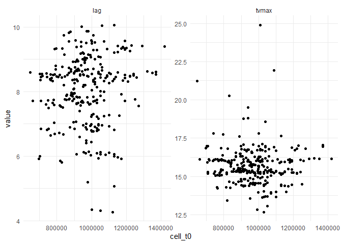

```r
data_phenot_parms_clean %>%
  filter(parameter %in% c("lag","tvmax","cell_t0")) %>%
  select(robot_id, parameter, value) %>%
  unique() %>%
  pivot_wider(names_from = parameter, values_from = value) %>%
  pivot_longer(cols = c("lag","tvmax"), names_to = "parameter",
               values_to = "value") %>%
  ggplot(aes(y = value, x = cell_t0)) +
  facet_wrap(~ parameter, scales = "free") +
  geom_point() +
  theme_minimal()
```

# 3 Flour effect

Pas d’effet flagrant.

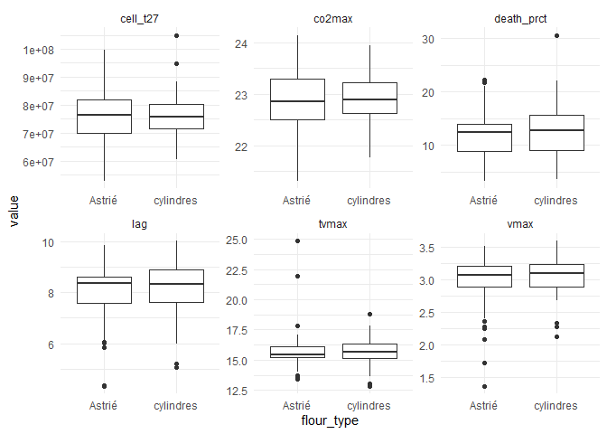

```r
data_phenot_parms_clean %>%
  filter(parameter != "cell_t0") %>%
  mutate(flour_id = strains$flour_id[match(strain_name, strains$strain_name)],
         flour_type = flours$mill_type[match(flour_id, flours$flour_id)]) %>%
  filter(!is.na(flour_type)) %>%
  ggplot() +
  aes(x = flour_type, y = value) +
  geom_boxplot() +
  facet_wrap(~parameter, scales = "free") +
  theme_minimal()
```

# Wheat type effect

Maybe a small effect on the `lag`

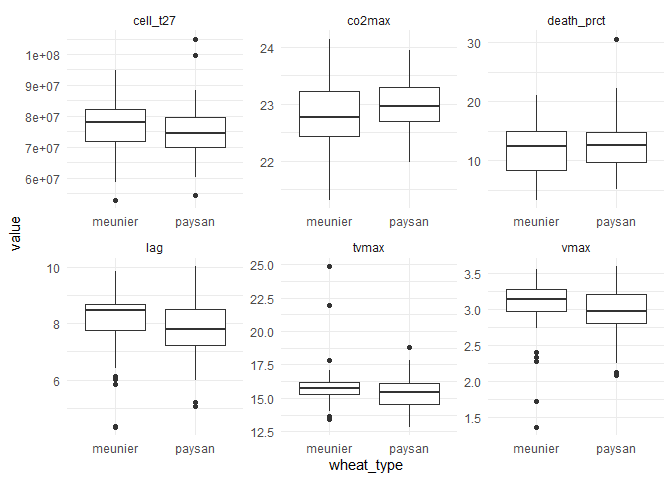

```r
data_phenot_parms_clean %>%
  filter(parameter != "cell_t0") %>%
  mutate(flour_id = strains$flour_id[match(strain_name, strains$strain_name)],
         wheat_type = flours$wheat_type[match(flour_id, flours$flour_id)]) %>%
  filter(!is.na(wheat_type)) %>%
  ggplot() +
  aes(x = wheat_type, y = value) +
  geom_boxplot() +
  facet_wrap(~ parameter, scales = "free") +
  theme_minimal()
```

# 4 Baker effect

Il y a un effet boulanger clair. Cet effet boulanger peut aussi être confondu avec un “*effet levure commerciale*” qui a pu coloniser l’ensemble des levains d’une même boulanger.

La position des souches commerciales sur la figure laisse supposer cette hypothèse de colonisation partiel des levains par les souches commerciales.

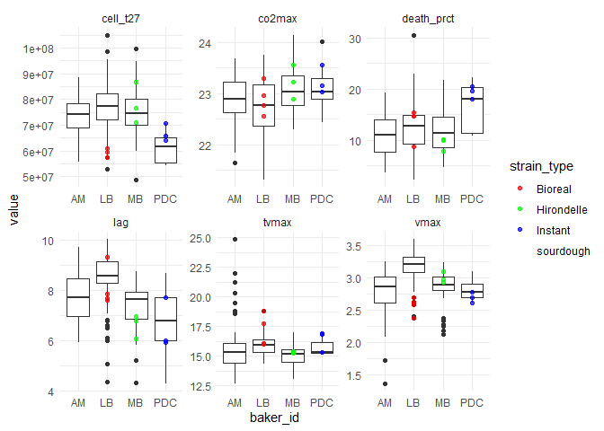

```r
data_phenot_parms_clean %>%
  filter(parameter != "cell_t0") %>%
  mutate(baker_id = strains$baker_id[match(strain_name, strains$strain_name)],
         strain_type = strains$strain_type[match(strain_name,
                                                 strains$strain_name)]) %>%
  filter(!is.na(baker_id)) %>%
  ggplot() +
  aes(x = baker_id, y = value) +
  geom_boxplot() +
  geom_point(aes(color = strain_type)) +
  scale_color_manual(values = strain_types_cols) +
  facet_wrap(~ parameter, scales = "free") +
  theme_minimal()
```

# 5 Backslopping effect

Pas d’effet clair

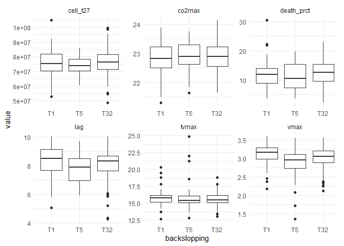

```r
data_phenot_parms_clean %>%
  filter(parameter != "cell_t0") %>%
  mutate(backslopping = strains$backslopping[match(strain_name,
                                                   strains$strain_name)]) %>%
  filter(!is.na(backslopping)) %>%
  ggplot() +
  aes(x = backslopping, y = value) +
  geom_boxplot() +
  facet_wrap(~parameter, scales = "free") +
  theme_minimal()
```

# 6 Block effect

## 6.1 For the complete data, regardless to the distribution of replicates in different blocks

Il semble y avoir un certain effet bloc sur `lag` et `vmax`.

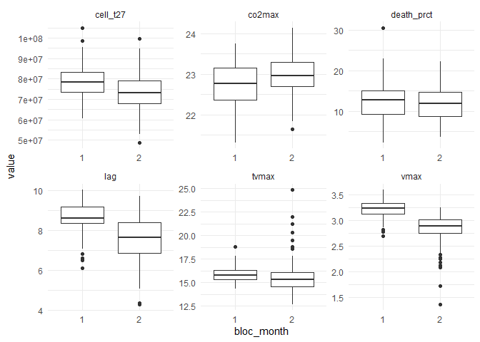

```r
data_phenot_parms_clean %>%
  filter(parameter != "cell_t0") %>%
  ggplot() +
  aes(x = bloc_month , y = value) +
  geom_boxplot() +
  facet_wrap(~parameter, scales = "free") +
  theme_minimal()
```

## 6.2 Only for the strains that are represented in both blocks

Only 6 strains have replicates in the two blocks. They are all from the same baker (=LB). So that is good because it is less crossed variables. But by evaluating the block effect only on these baker’s strains, we make the assumption that there is no interaction between `block` and `baker` variables : assumption that makes sense to me. I don’t see how we could have an interaction between them.

These 6 strains have 6 replicates each of them, 3 in each month bloc.

```r
strains_in_both <- data_phenot_parms_clean %>%
  select(strain_name, bloc_month) %>%
  unique() %>%
  group_by(strain_name) %>%
  summarise(n = n()) %>%
  filter(n > 1) %>%
  select(strain_name) %>%
  flatten_chr()

strains_in_both
```

```
## [1] "LB-GP4-T1-10"  "LB-PD7-T32-3"  "LB-RG15-T1-1"  "LB-RT17-T32-1"
## [5] "LB-SP22-T32-3" "LB-SR24-T1-23"
```

```r
length(strains_in_both)
```

```
## [1] 6
```

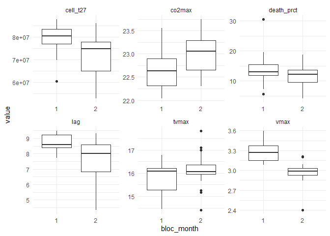

```r
data_phenot_parms_clean %>%
  filter(parameter != "cell_t0",
         strain_name %in% strains_in_both) %>%
  ggplot() +
  aes(x = bloc_month , y = value) +
  geom_boxplot() +
  facet_wrap(~parameter, scales = "free") +
  theme_minimal()
```

# 7 Analysis

## 7.1 Classic analysis with a linear mixed model

### 7.1.1 Model formulation

The most complex model includes :

- Fixed effects
  - `strain_name` = 3 replicates for each strain
  - `baker_id` = 4 levels (AM, LB, MB, PDC)
  - `flour_type` = 2 levels (*Astrié* and *cylindre*)
  - `wheat_type` = 2 levels (*meunier* and *paysan*)
  - `backslopping` = 3 levels (*T1*, *T5* and *T32*)
- Random effects
  - `bloc_month` = experimental block corresponding to the month of the experimentation. `1` is for September 2021 and `2` is for December 2021.
  - `cell_t0` = number of cells at the moment of the inoculation.

The model is defined as follow. The $\beta$ coefficients for each level of strain_name are not displayed for clarity.

$$\begin{aligned}
\operatorname{phenotype}_{i} &\sim N \left(\mu, \sigma^2 \right) \\
\mu &=\alpha_{j[i],k[i]} + \beta_{1}(\operatorname{flour\_type}_{\operatorname{cylindres}}) + \beta_{2}(\operatorname{wheat\_type}_{\operatorname{paysan}}) + \beta_{3}(\operatorname{backslopping}_{\operatorname{T5}})\ + \\
&\quad \beta_{4}(\operatorname{backslopping}_{\operatorname{T32}}) + \beta_{5}(\operatorname{baker\_id}_{\operatorname{LB}}) + \beta_{6}(\operatorname{baker\_id}_{\operatorname{MB}}) + \beta_{7}(\operatorname{baker\_id}_{\operatorname{PDC}})\ + \\
&\quad \beta_{8}(\operatorname{flour\_type}_{\operatorname{cylindres}} \times \operatorname{wheat\_type}_{\operatorname{paysan}}) \\
\alpha_{j} &\sim N \left(\mu_{\alpha_{j}}, \sigma^2_{\alpha_{j}} \right)
\text{, for cell_t0 j = 1,} \dots \text{,J} \\
\alpha_{k} &\sim N \left(\mu_{\alpha_{k}}, \sigma^2_{\alpha_{k}} \right)
\text{, for bloc_month k = 1,} \dots \text{,K}
\end{aligned}$$

### 7.1.2 Model versions

Each versions of the model are specified with combinations of these abbreviations :

- `strain_name` = `sn`
- `baker_id` = `bk`
- `flour_type` = `ft`
- `wheat_type` = `wt`
- `backslopping` = `bs`
- `bloc_month` = `bm`
- `cell_t0` = `c0`

When the abbrev. is preceded by a `R` it means that it is taken as random effects on the intercept.

The fitted models are :

- `fit_sn_ft_wt_bs_bk_Rbm_Rc0` (complete model)
- `fit_sn_ft_wt_bs_bk` (without random effect)
- `fit_sn_Rbm_Rc0` (with only the strain as a fixed effect and both random effects)
- `fit_sn` (with only the strain as a fixed effect)
- `fit_Rsn_Rbm_Rc0` (with only random effect, and including strain as a random effect)
- `fit_ft_wt_bs_bk_Rbm_Rc0` (without the strain fixed effec but with all other effects)
- `fit_ft_wt_bk_Rbm_Rc0`
- `fit_ft_wt_bs_Rbm_Rc0`
- `fit_bk_Rbm_Rc0`
- `fit_bk_Rbm_Rc0_Rsn`
- `fit_ft_wt_bs_bk_Rbm_Rc0_Rsn` (strain effect as random effect and all other effects)

### 7.1.3 Fitting…

```r
fits <- data_phenot_parms_clean %>%
  filter(parameter != "cell_t0") %>%
  mutate(flour_id = strains$flour_id[match(strain_name, strains$strain_name)],
         baker_id = strains$baker_id[match(strain_name, strains$strain_name)],
         flour_type = flours$mill_type[match(flour_id, flours$flour_id)],
         wheat_type = flours$wheat_type[match(flour_id, flours$flour_id)],
         backslopping = strains$backslopping[match(strain_name,
                                                   strains$strain_name)],
         cell_t0 = data_cyto$cell_t0[match(robot_id, data_cyto$robot_id)]) %>%
  filter(!if_any(everything(), ~ is.na(.x))) %>%
  group_by(parameter) %>%
  nest() %>%
  mutate(fit_sn_ft_wt_bs_bk_Rbm_Rc0 = map(data, ~ lmer(value ~ strain_name
                                                       + flour_type * wheat_type
                                                       + backslopping + baker_id
                                                       + (1|bloc_month)
                                                       + (1|cell_t0),
                                                       data = .)),
         fit_sn_ft_wt_bs_bk = map(data, ~ lm(value ~ strain_name + flour_type
                                             * wheat_type + backslopping +
                                               baker_id, data = .)),
         fit_sn_Rbm_Rc0 = map(data, ~ lmer(value ~ strain_name + (1|bloc_month)
                                           + (1|cell_t0), data = .)),
         fit_sn = map(data, ~ lm(value ~ strain_name, data = .)),
         fit_Rsn_Rbm_Rc0 = map(data, ~ lmer(value ~ 1 + (1|strain_name)
                                            + (1|bloc_month) + (1|cell_t0),
                                            data = .)),
         fit_ft_wt_bs_bk_Rbm_Rc0 =  map(data, ~ lmer(value ~ flour_type
                                                     * wheat_type + backslopping
                                                     + baker_id + (1|bloc_month)
                                                     + (1|cell_t0), data = .)),
         fit_ft_wt_bk_Rbm_Rc0 =  map(data, ~ lmer(value ~ flour_type
                                                  * wheat_type + baker_id
                                                  + (1|bloc_month)
                                                  + (1|cell_t0), data = .)),
         fit_ft_wt_bs_Rbm_Rc0 =  map(data, ~ lmer(value ~ flour_type
                                                  * wheat_type + backslopping
                                                  + (1|bloc_month)
                                                  + (1|cell_t0), data = .)),
         fit_bk_Rbm_Rc0 =  map(data, ~ lmer(value ~ baker_id
                                            + (1|bloc_month)
                                            + (1|cell_t0), data = .)),
         fit_bk_Rbm_Rc0_Rsn =  map(data, ~ lmer(value ~ baker_id
                                                + (1|bloc_month)
                                                + (1|cell_t0)
                                                + (1|strain_name), data = .)),
         fit_ft_wt_bs_bk_Rbm_Rc0_Rsn = map(data, ~ lmer(value ~ flour_type
                                                        * wheat_type
                                                        + backslopping
                                                        + baker_id
                                                        + (1|bloc_month)
                                                        + (1|cell_t0)
                                                        + (1|strain_name),
                                                        data = .))) %>%

  pivot_longer(cols = starts_with("fit_"), names_to = "fit_name",
               values_to = "fit")
```

```
## fixed-effect model matrix is rank deficient so dropping 8 columns / coefficients
## fixed-effect model matrix is rank deficient so dropping 8 columns / coefficients
## fixed-effect model matrix is rank deficient so dropping 8 columns / coefficients
## fixed-effect model matrix is rank deficient so dropping 8 columns / coefficients
```

```
## boundary (singular) fit: see ?isSingular
```

```
## fixed-effect model matrix is rank deficient so dropping 8 columns / coefficients
## fixed-effect model matrix is rank deficient so dropping 8 columns / coefficients
```

[output not shown]

### 7.1.4 Issues while running models

The most complete model -including coefficients for each modality of strains (i.e. strain names) as variables- did not manage to include all variable because of a *rank deficiency* (see warnings above). This means that there are maybe to many parameters for the number of observations (which makes sense with this quantity of modalities).

The effective model version that ran instead of this complete model, is a model including only the `strain_name` variable and both `Rbm` and `Rc0` random effects. This model is exactly the model `fit_sn_Rbm_Rc0`.

### 7.1.5 Goodness-of-fit

| parameter | fit_name | logLik | AIC | deltaAIC | sigma | REMLcrit | df.residual |
| --- | --- | --- | --- | --- | --- | --- | --- |
| cell_t27 | **~ sn + ft + wt + bs + bk + Rbm + Rc0** | -2460.2 | 5050.4 | 0.0 | 7036361.6 | 4920.4 | 138 |
| cell_t27 | **~ sn + Rbm + Rc0** | -2460.2 | 5050.4 | 0.0 | 7036361.6 | 4920.4 | 138 |
| cell_t27 | ~ ft + wt + bs + bk + Rbm + Rc0 + Rsn | -3361.5 | 6749.0 | 1698.5 | 6929134.7 | 6723.0 | 190 |
| cell_t27 | ~ ft + wt + bs + bk + Rbm + Rc0 | -3363.8 | 6751.7 | 1701.3 | 7403145.9 | 6727.7 | 191 |
| cell_t27 | ~ ft + wt + bk + Rbm + Rc0 | -3395.8 | 6811.7 | 1761.2 | 7375678.3 | 6791.7 | 193 |
| cell_t27 | ~ ft + wt + bs + Rbm + Rc0 | -3416.8 | 6851.6 | 1801.1 | 7522479.0 | 6833.6 | 194 |
| cell_t27 | ~ bk + Rbm + Rc0 + Rsn | -3439.5 | 6895.1 | 1844.7 | 6891331.0 | 6879.1 | 195 |
| cell_t27 | ~ bk + Rbm + Rc0 | -3441.7 | 6897.4 | 1847.0 | 7322988.0 | 6883.4 | 196 |
| cell_t27 | ~ Rsn + Rbm + Rc0 | -3491.3 | 6992.7 | 1942.3 | 6867875.7 | 6982.7 | 198 |
| cell_t27 | ~ sn + ft + wt + bs + bk | -3457.5 | 7041.0 | 1990.6 | 7241033.4 | NA | 141 |
| cell_t27 | ~ sn | -3457.5 | 7041.0 | 1990.6 | 7241033.4 | NA | 141 |
| co2max | **~ Rsn + Rbm + Rc0** | -136.5 | 283.1 | 0.0 | 0.5 | 273.1 | 198 |
| co2max | ~ bk + Rbm + Rc0 | -138.7 | 291.4 | 8.3 | 0.5 | 277.4 | 196 |
| co2max | ~ bk + Rbm + Rc0 + Rsn | -138.7 | 293.4 | 10.3 | 0.5 | 277.4 | 195 |
| co2max | ~ ft + wt + bs + Rbm + Rc0 | -141.6 | 301.3 | 18.2 | 0.5 | 283.3 | 194 |
| co2max | ~ ft + wt + bk + Rbm + Rc0 | -141.0 | 301.9 | 18.8 | 0.5 | 281.9 | 193 |
| co2max | ~ ft + wt + bs + bk + Rbm + Rc0 | -141.7 | 307.4 | 24.3 | 0.5 | 283.4 | 191 |
| co2max | ~ ft + wt + bs + bk + Rbm + Rc0 + Rsn | -141.7 | 309.4 | 26.3 | 0.5 | 283.4 | 190 |
| co2max | ~ sn + ft + wt + bs + bk | -100.7 | 327.4 | 44.3 | 0.5 | NA | 141 |
| co2max | ~ sn | -100.7 | 327.4 | 44.3 | 0.5 | NA | 141 |
| co2max | ~ sn + ft + wt + bs + bk + Rbm + Rc0 | -130.7 | 391.4 | 108.3 | 0.5 | 261.4 | 138 |
| co2max | ~ sn + Rbm + Rc0 | -130.7 | 391.4 | 108.3 | 0.5 | 261.4 | 138 |
| death_prct | **~ sn + ft + wt + bs + bk + Rbm + Rc0** | -440.1 | 1010.3 | 0.0 | 4.0 | 880.3 | 138 |
| death_prct | **~ sn + Rbm + Rc0** | -440.1 | 1010.3 | 0.0 | 4.0 | 880.3 | 138 |
| death_prct | ~ ft + wt + bs + bk + Rbm + Rc0 | -576.2 | 1176.3 | 166.0 | 4.3 | 1152.3 | 191 |
| death_prct | ~ ft + wt + bs + bk + Rbm + Rc0 + Rsn | -575.7 | 1177.4 | 167.1 | 4.1 | 1151.4 | 190 |
| death_prct | ~ ft + wt + bk + Rbm + Rc0 | -579.1 | 1178.2 | 167.9 | 4.3 | 1158.2 | 193 |
| death_prct | ~ bk + Rbm + Rc0 | -582.9 | 1179.8 | 169.5 | 4.3 | 1165.8 | 196 |
| death_prct | ~ bk + Rbm + Rc0 + Rsn | -582.5 | 1181.0 | 170.7 | 4.1 | 1165.0 | 195 |
| death_prct | ~ ft + wt + bs + Rbm + Rc0 | -581.6 | 1181.2 | 170.9 | 4.2 | 1163.2 | 194 |
| death_prct | ~ Rsn + Rbm + Rc0 | -587.5 | 1184.9 | 174.6 | 4.1 | 1174.9 | 198 |
| death_prct | ~ sn + ft + wt + bs + bk | -546.0 | 1217.9 | 207.6 | 4.3 | NA | 141 |
| death_prct | ~ sn | -546.0 | 1217.9 | 207.6 | 4.3 | NA | 141 |
| lag | **~ Rsn + Rbm + Rc0** | -264.5 | 538.9 | 0.0 | 0.9 | 528.9 | 198 |
| lag | ~ bk + Rbm + Rc0 | -264.5 | 543.0 | 4.1 | 0.9 | 529.0 | 196 |
| lag | ~ bk + Rbm + Rc0 + Rsn | -264.5 | 545.0 | 6.1 | 0.9 | 529.0 | 195 |
| lag | ~ ft + wt + bs + bk + Rbm + Rc0 | -264.1 | 552.2 | 13.3 | 0.9 | 528.2 | 191 |
| lag | ~ ft + wt + bk + Rbm + Rc0 | -266.4 | 552.8 | 13.9 | 0.9 | 532.8 | 193 |
| lag | ~ ft + wt + bs + bk + Rbm + Rc0 + Rsn | -264.1 | 554.2 | 15.3 | 0.9 | 528.2 | 190 |
| lag | ~ ft + wt + bs + Rbm + Rc0 | -268.4 | 554.7 | 15.8 | 0.9 | 536.7 | 194 |
| lag | ~ sn + ft + wt + bs + bk + Rbm + Rc0 | -223.4 | 576.8 | 37.9 | 0.9 | 446.8 | 138 |
| lag | ~ sn + Rbm + Rc0 | -223.4 | 576.8 | 37.9 | 0.9 | 446.8 | 138 |
| lag | ~ sn + ft + wt + bs + bk | -240.1 | 606.3 | 67.4 | 0.9 | NA | 141 |
| lag | ~ sn | -240.1 | 606.3 | 67.4 | 0.9 | NA | 141 |
| tvmax | **~ sn + ft + wt + bs + bk + Rbm + Rc0** | -207.9 | 545.9 | 0.0 | 0.8 | 415.9 | 138 |
| tvmax | **~ sn + Rbm + Rc0** | -207.9 | 545.9 | 0.0 | 0.8 | 415.9 | 138 |
| tvmax | **~ sn + ft + wt + bs + bk** | -210.9 | 547.7 | 1.9 | 0.8 | NA | 141 |
| tvmax | **~ sn** | -210.9 | 547.7 | 1.9 | 0.8 | NA | 141 |
| tvmax | ~ bk + Rbm + Rc0 + Rsn | -300.7 | 617.4 | 71.5 | 0.8 | 601.4 | 195 |
| tvmax | ~ Rsn + Rbm + Rc0 | -306.6 | 623.3 | 77.4 | 0.8 | 613.3 | 198 |
| tvmax | ~ ft + wt + bs + bk + Rbm + Rc0 + Rsn | -299.7 | 625.5 | 79.6 | 0.8 | 599.5 | 190 |
| tvmax | ~ bk + Rbm + Rc0 | -319.3 | 652.7 | 106.8 | 1.1 | 638.7 | 196 |
| tvmax | ~ ft + wt + bk + Rbm + Rc0 | -320.7 | 661.5 | 115.6 | 1.2 | 641.5 | 193 |
| tvmax | ~ ft + wt + bs + bk + Rbm + Rc0 | -320.6 | 665.2 | 119.4 | 1.2 | 641.2 | 191 |
| tvmax | ~ ft + wt + bs + Rbm + Rc0 | -328.1 | 674.2 | 128.3 | 1.2 | 656.2 | 194 |
| vmax | **~ sn + ft + wt + bs + bk** | 59.1 | 7.8 | 0.0 | 0.2 | NA | 141 |
| vmax | **~ sn** | 59.1 | 7.8 | 0.0 | 0.2 | NA | 141 |
| vmax | ~ Rsn + Rbm + Rc0 | -3.6 | 17.1 | 9.3 | 0.2 | 7.1 | 198 |
| vmax | ~ bk + Rbm + Rc0 + Rsn | -3.4 | 22.8 | 15.0 | 0.2 | 6.8 | 195 |
| vmax | ~ bk + Rbm + Rc0 | -8.0 | 30.0 | 22.2 | 0.2 | 16.0 | 196 |
| vmax | ~ ft + wt + bs + Rbm + Rc0 | -13.7 | 45.5 | 37.7 | 0.2 | 27.5 | 194 |
| vmax | ~ ft + wt + bs + bk + Rbm + Rc0 + Rsn | -10.1 | 46.3 | 38.4 | 0.2 | 20.3 | 190 |
| vmax | ~ ft + wt + bk + Rbm + Rc0 | -14.0 | 47.9 | 40.1 | 0.2 | 27.9 | 193 |
| vmax | ~ ft + wt + bs + bk + Rbm + Rc0 | -14.8 | 53.6 | 45.8 | 0.2 | 29.6 | 191 |
| vmax | ~ sn + ft + wt + bs + bk + Rbm + Rc0 | -13.2 | 156.4 | 148.5 | 0.2 | 26.4 | 138 |
| vmax | ~ sn + Rbm + Rc0 | -13.2 | 156.4 | 148.5 | 0.2 | 26.4 | 138 |

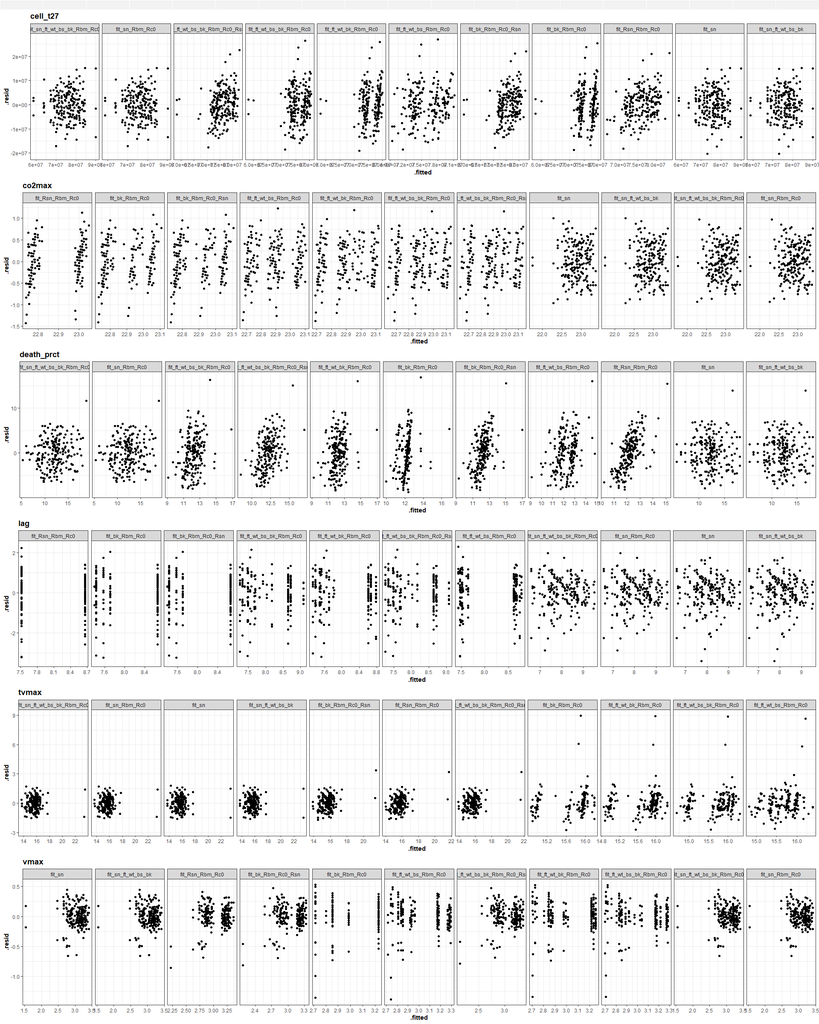

```r
res_fitted_plots <- fits %>%
  mutate(summary = map(fit, augment),
         AIC = map_dbl(fit, ~ unlist(glance(.x))['AIC'])) %>%
  arrange(parameter, AIC) %>%
  unnest(summary) %>%
  select(-data, -fit) %>%
  group_by(parameter) %>%
  nest() %>%
  mutate(data = map(data, ~ .x %>% mutate(fit_name = fct_reorder(fit_name, AIC))),
         plots = map2(data, parameter,
                      ~ ggplot(data = .x) +
                        aes(x = .fitted, y = .resid) +
                        geom_point() +
                        facet_grid(. ~ fit_name, scales = "free") +
                        theme_bw() +
                        ggtitle(.y) +
                        theme(strip.text.y = element_text(angle = 0),
                              title = element_text(face = "bold")))) %>%
  select(plots, parameter) %>%
  as.list()

gridExtra::arrangeGrob(grobs = res_fitted_plots$plots, ncol = 1, nrow = length(unique(fits$parameter)), top = "", ) %>%
  plot()
```

## 7.2 Analysis with block effect correction

```r
glimpse(data_phenot_parms_clean)
```

```
## Rows: 1,995
## Columns: 6
## $ robot_id    <chr> "R20-20210930-001", "R20-20210930-001", "R20-20210930-001"~
## $ strain_name <chr> "LB-PD7-T1-1", "LB-PD7-T1-1", "LB-PD7-T1-1", "LB-PD7-T1-1"~
## $ bloc        <fct> 3, 3, 3, 3, 3, 3, 3, 3, 3, 3, 3, 3, 3, 3, 3, 3, 3, 3, 3, 3~
## $ bloc_month  <fct> 1, 1, 1, 1, 1, 1, 1, 1, 1, 1, 1, 1, 1, 1, 1, 1, 1, 1, 1, 1~
## $ parameter   <chr> "cell_t0", "cell_t27", "co2max", "death_prct", "lag", "tvm~
## $ value       <dbl> 9.810000e+05, 7.640000e+07, 2.223684e+01, 1.330000e+01, 9.~
```

## 7.3 Block effects estimation

Lists of strains that are in both blocs

```r
strains_in_both <- data_phenot_parms_clean %>%
  select(strain_name, bloc_month) %>%
  unique() %>%
  group_by(strain_name) %>%
  summarise(n = n()) %>%
  filter(n > 1) %>%
  select(strain_name) %>%
  flatten_chr()

strains_in_both
```

```
## [1] "LB-GP4-T1-10"  "LB-PD7-T32-3"  "LB-RG15-T1-1"  "LB-RT17-T32-1"
## [5] "LB-SP22-T32-3" "LB-SR24-T1-23"
```

```r
length(strains_in_both)
```

```
## [1] 6
```

Estimation of block effect as a fix effect

```r
fits_blockeff_estim <- data_phenot_parms_clean %>%
  filter(parameter != "cell_t0",
         strain_name %in% strains_in_both) %>%
  mutate(flour_id = strains$flour_id[match(strain_name, strains$strain_name)],
         baker_id = strains$baker_id[match(strain_name, strains$strain_name)],
         flour_type = flours$mill_type[match(flour_id, flours$flour_id)],
         wheat_type = flours$wheat_type[match(flour_id, flours$flour_id)],
         backslopping = strains$backslopping[match(strain_name, strains$strain_name)],
         cell_t0 = data_cyto$cell_t0[match(robot_id, data_cyto$robot_id)]) %>%
  # filter(!if_any(everything(), ~ is.na(.x))) %>%
  group_by(parameter) %>%
  nest() %>%

  # Estimation of the block effect as a random effect and as a fixed effect. baker_id is removed of the model because there is only one baker in this data
  mutate(fit_block_ranef = map(data, ~ lmer(value ~ flour_type * wheat_type + backslopping + (1|bloc_month) + (1|cell_t0) + (1|strain_name), data = .)),
         fit_block_fixef = map(data, ~ lm(value ~ bloc_month * cell_t0 * strain_name, data = .))) %>%
  mutate(ranef_bloc_int = map_dbl(fit_block_ranef, ~ summary(.x)$coeff[1,1]),
         ranef_bloc_1 = map_dbl(fit_block_ranef, ~ ranef(.x)$bloc_month[1,1]),
         ranef_bloc_2 = map_dbl(fit_block_ranef, ~ ranef(.x)$bloc_month[2,1]),
         fixef_bloc_int = map_dbl(fit_block_fixef,
                                  ~ .x$coefficients["bloc_month2"]),
         fixef_bloc_1 = - fixef_bloc_int/2,
         fixef_bloc_2 = fixef_bloc_int/2,
         p = map_dbl(fit_block_fixef, ~ anova(.x)$P[1])) %>%
  select(-data, -fit_block_fixef) %>%
  ungroup() %>%
  mutate(p_adj = p.adjust(p, method = "BH"))
```

Residual vs Fitted values :

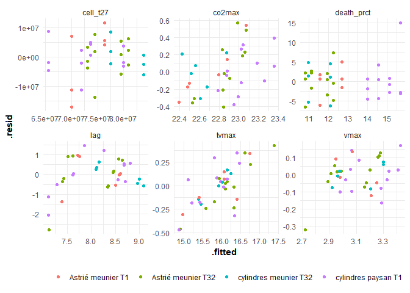

```r
fits_blockeff_estim %>%
  mutate(summary = map(fit_block_ranef, augment)) %>%
  unnest(summary) %>%
  select(parameter, flour_type, wheat_type, backslopping, .fitted, .resid) %>%
  ggplot() +
  aes(x = .fitted, y = .resid, color = paste(flour_type, wheat_type, backslopping)) +
  geom_point() +
  facet_wrap(~ parameter, scales = "free") +
  theme_minimal() +
  scale_color_discrete(name = "") +
  theme(strip.text.y = element_text(angle = 0),
        title = element_text(face = "bold"),
        legend.position = "bottom")
```

## 7.4 Model fitting after block effect removal

### 7.4.1 Correction of values

```r
fits_blockeff_corr <- data_phenot_parms_clean %>%
  filter(parameter != "cell_t0") %>%
  mutate(flour_id = strains$flour_id[match(strain_name, strains$strain_name)],
         baker_id = strains$baker_id[match(strain_name, strains$strain_name)],
         flour_type = flours$mill_type[match(flour_id, flours$flour_id)],
         wheat_type = flours$wheat_type[match(flour_id, flours$flour_id)],
         backslopping = strains$backslopping[match(strain_name,
                                                   strains$strain_name)],
         cell_t0 = data_cyto$cell_t0[match(robot_id, data_cyto$robot_id)]) %>%

  mutate(fixef_bloc_1 = fits_blockeff_estim$fixef_bloc_1[match(parameter,
                                                               fits_blockeff_estim$parameter)],
         fixef_bloc_2 = fits_blockeff_estim$fixef_bloc_2[match(parameter,
                                                               fits_blockeff_estim$parameter)],
         valueC = ifelse(bloc_month == 1,
                         value - fixef_bloc_1,
                         value - fixef_bloc_2))
```

### 7.4.2 Let’s have a look to this correction : hum, maybe it did not work :/

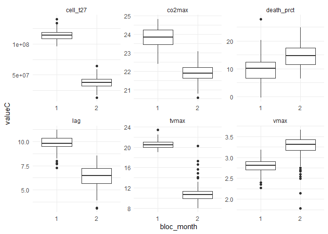

```r
ggplot(fits_blockeff_corr) +
  aes(x = bloc_month, y = valueC) +
  geom_boxplot() +
  facet_wrap(~ parameter, scales = "free") +
  theme_minimal()
```

#### 7.4.2.1 BELOW, NOT OK

Fitting :

```r
fits_blockeff_corr %<>%
  # filter(!if_any(everything(), ~ is.na(.x))) %>%
  group_by(parameter) %>%
  nest() %>%
  mutate(fit_sn_ft_wt_bs_bk_Rc0 = map(data, ~ lmer(valueC ~ strain_name
                                                       + flour_type * wheat_type
                                                       + backslopping + baker_id
                                                       + (1|cell_t0),
                                                       data = .)),
         fit_sn_ft_wt_bs_bk = map(data, ~ lm(valueC ~ strain_name + flour_type
                                             * wheat_type + backslopping +
                                               baker_id, data = .)),
         fit_sn_Rc0 = map(data, ~ lmer(valueC ~ strain_name + (1|cell_t0),
                                       data = .)),
         fit_sn = map(data, ~ lm(valueC ~ strain_name, data = .)),
         fit_Rsn_Rc0 = map(data, ~ lmer(valueC ~ 1 + (1|strain_name)
                                        + (1|cell_t0),
                                            data = .)),
         fit_ft_wt_bs_bk_Rc0 =  map(data, ~ lmer(valueC ~ flour_type
                                                     * wheat_type + backslopping
                                                     + baker_id + (1|cell_t0),
                                                     data = .)),
         fit_ft_wt_bk_Rc0 =  map(data, ~ lmer(valueC ~ flour_type
                                                  * wheat_type + baker_id
                                                  + (1|cell_t0), data = .)),
         fit_ft_wt_bs_Rc0 =  map(data, ~ lmer(valueC ~ flour_type
                                                  * wheat_type + backslopping
                                                  + (1|cell_t0), data = .)),
         fit_bk_Rc0 =  map(data, ~ lmer(valueC ~ baker_id
                                            + (1|cell_t0), data = .)),
         fit_bk_Rc0_Rsn =  map(data, ~ lmer(valueC ~ baker_id
                                                + (1|cell_t0)
                                                + (1|strain_name), data = .)),
         fit_ft_wt_bs_bk_Rc0_Rsn = map(data, ~ lmer(valueC ~ flour_type
                                                        * wheat_type
                                                        + backslopping
                                                        + baker_id
                                                        + (1|cell_t0)
                                                        + (1|strain_name),
                                                        data = .))) %>%

  pivot_longer(cols = starts_with("fit_"), names_to = "fit_name",
               values_to = "fit")
```

Infos :

```r
fits_blockeff_corr %>%
  mutate(summary = map(fit, glance)) %>%
  unnest(summary) %>%
  select(-data, -fit) %>%
  arrange(parameter, AIC) %>%
  group_by(parameter) %>%
  mutate(deltaAIC = AIC - min(AIC)) %>%
  select(parameter, fit_name, logLik, AIC, deltaAIC, sigma, REMLcrit, df.residual) %>%
  mutate_if(is.numeric, ~ round(.x, 1)) %>%
  mutate(fit_name = str_replace_all(fit_name, "^fit_", "~ "),
         fit_name = str_replace_all(fit_name, "_", " + "),
         fit_name = ifelse(deltaAIC < 2, str_replace_all(fit_name, "^", "**"), fit_name),
         fit_name = ifelse(deltaAIC < 2, str_replace_all(fit_name, "$", "**"), fit_name)) %>%
  knitr::kable(format = "html", align = "rlrrrrrr") %>%
  kableExtra::kable_styling() %>%
  kableExtra::row_spec(seq(length(unique(fits$fit_name)), nrow(fits), length(unique(fits$fit_name))), hline_after = T) %>%
  kableExtra::scroll_box(width = "100%", height = "500px")
```

| parameter | fit_name | logLik | AIC | deltaAIC | sigma | REMLcrit | df.residual |
| --- | --- | --- | --- | --- | --- | --- | --- |
| cell_t27 | **~ sn + ft + wt + bs + bk + Rc0** | -2613.5 | 5354.9 | 0.0 | 21029789.2 | 5226.9 | 139 |
| cell_t27 | ~ ft + wt + bs + bk + Rc0 + Rsn | -3569.8 | 7163.5 | 1808.6 | 20215868.7 | 7139.5 | 191 |
| cell_t27 | ~ ft + wt + bs + bk + Rc0 | -3577.2 | 7176.3 | 1821.4 | 22775436.0 | 7154.3 | 192 |
| cell_t27 | ~ ft + wt + bk + Rc0 | -3611.9 | 7241.9 | 1886.9 | 22688792.6 | 7223.9 | 194 |
| cell_t27 | ~ sn + Rc0 | -3607.4 | 7396.8 | 2041.8 | 18371403.6 | 7214.8 | 194 |
| cell_t27 | ~ ft + wt + bs + Rc0 | -3708.2 | 7432.4 | 2077.5 | 32280510.3 | 7416.4 | 195 |
| cell_t27 | ~ sn + ft + wt + bs + bk | -3673.9 | 7473.9 | 2118.9 | 21029789.2 | NA | 141 |
| cell_t27 | ~ bk + Rc0 + Rsn | -5137.4 | 10288.8 | 4933.9 | 17745538.0 | 10274.8 | 278 |
| cell_t27 | ~ bk + Rc0 | -5159.5 | 10331.1 | 4976.1 | 21823556.1 | 10319.1 | 279 |
| cell_t27 | ~ sn | -5118.0 | 10416.1 | 5061.2 | 18371403.6 | NA | 196 |
| cell_t27 | ~ Rsn + Rc0 | -5268.8 | 10545.6 | 5190.7 | 18300333.5 | 10537.6 | 281 |
| co2max | **~ ft + wt + bs + bk + Rc0 + Rsn** | -215.8 | 455.6 | 0.0 | 0.6 | 431.6 | 191 |
| co2max | ~ sn + ft + wt + bs + bk | -166.4 | 458.8 | 3.2 | 0.7 | NA | 141 |
| co2max | ~ ft + wt + bs + bk + Rc0 | -219.6 | 461.3 | 5.7 | 0.7 | 439.3 | 192 |
| co2max | ~ ft + wt + bk + Rc0 | -221.8 | 461.7 | 6.1 | 0.7 | 443.7 | 194 |
| co2max | ~ sn + ft + wt + bs + bk + Rc0 | -177.2 | 482.4 | 26.8 | 0.7 | 354.4 | 139 |
| co2max | ~ ft + wt + bs + Rc0 | -284.3 | 584.6 | 128.9 | 1.0 | 568.6 | 195 |
| co2max | ~ bk + Rc0 + Rsn | -289.9 | 593.7 | 138.1 | 0.6 | 579.7 | 278 |
| co2max | ~ bk + Rc0 | -298.7 | 609.3 | 153.7 | 0.7 | 597.3 | 279 |
| co2max | ~ sn | -215.4 | 610.9 | 155.2 | 0.6 | NA | 196 |
| co2max | ~ sn + Rc0 | -235.8 | 653.5 | 197.9 | 0.6 | 471.5 | 194 |
| co2max | ~ Rsn + Rc0 | -358.9 | 725.9 | 270.2 | 0.6 | 717.9 | 281 |
| death_prct | **~ sn + ft + wt + bs + bk + Rc0** | -441.9 | 1011.8 | 0.0 | 4.1 | 883.8 | 139 |
| death_prct | ~ ft + wt + bs + bk + Rc0 + Rsn | -581.7 | 1187.3 | 175.5 | 4.1 | 1163.3 | 191 |
| death_prct | ~ ft + wt + bs + bk + Rc0 | -583.9 | 1189.7 | 177.9 | 4.5 | 1167.7 | 192 |
| death_prct | ~ ft + wt + bk + Rc0 | -587.4 | 1192.7 | 181.0 | 4.5 | 1174.7 | 194 |
| death_prct | ~ ft + wt + bs + Rc0 | -601.4 | 1218.8 | 207.0 | 4.7 | 1202.8 | 195 |
| death_prct | ~ sn + ft + wt + bs + bk | -547.9 | 1221.9 | 210.1 | 4.3 | NA | 141 |
| death_prct | ~ sn + Rc0 | -616.6 | 1415.1 | 403.3 | 4.3 | 1233.1 | 194 |
| death_prct | ~ bk + Rc0 + Rsn | -828.7 | 1671.5 | 659.7 | 4.2 | 1657.5 | 278 |
| death_prct | ~ bk + Rc0 | -830.8 | 1673.6 | 661.8 | 4.5 | 1661.6 | 279 |
| death_prct | ~ sn | -769.2 | 1718.4 | 706.6 | 4.3 | NA | 196 |
| death_prct | ~ Rsn + Rc0 | -856.9 | 1721.9 | 710.1 | 4.2 | 1713.9 | 281 |
| lag | **~ sn + ft + wt + bs + bk + Rc0** | -268.3 | 664.5 | 0.0 | 1.2 | 536.5 | 139 |
| lag | ~ ft + wt + bs + bk + Rc0 + Rsn | -338.9 | 701.9 | 37.3 | 1.2 | 677.9 | 191 |
| lag | ~ ft + wt + bk + Rc0 | -342.3 | 702.5 | 38.0 | 1.3 | 684.5 | 194 |
| lag | ~ ft + wt + bs + bk + Rc0 | -342.2 | 706.3 | 41.8 | 1.3 | 684.3 | 192 |
| lag | ~ sn + ft + wt + bs + bk | -298.3 | 722.5 | 58.0 | 1.3 | NA | 141 |
| lag | ~ ft + wt + bs + Rc0 | -402.2 | 820.4 | 155.9 | 1.7 | 804.4 | 195 |
| lag | ~ sn + Rc0 | -360.2 | 902.4 | 237.8 | 1.1 | 720.4 | 194 |
| lag | ~ bk + Rc0 + Rsn | -463.3 | 940.7 | 276.1 | 1.1 | 926.7 | 278 |
| lag | ~ bk + Rc0 | -469.3 | 950.5 | 286.0 | 1.2 | 938.5 | 279 |
| lag | ~ sn | -396.7 | 973.5 | 308.9 | 1.2 | NA | 196 |
| lag | ~ Rsn + Rc0 | -539.0 | 1085.9 | 421.4 | 1.1 | 1077.9 | 281 |
| tvmax | **~ sn + ft + wt + bs + bk + Rc0** | -359.4 | 846.8 | 0.0 | 2.4 | 718.8 | 139 |
| tvmax | ~ ft + wt + bs + bk + Rc0 + Rsn | -477.0 | 978.0 | 131.2 | 2.3 | 954.0 | 191 |
| tvmax | ~ sn + ft + wt + bs + bk | -428.8 | 983.5 | 136.7 | 2.4 | NA | 141 |
| tvmax | ~ ft + wt + bs + bk + Rc0 | -487.6 | 997.2 | 150.4 | 2.8 | 975.2 | 192 |
| tvmax | ~ ft + wt + bk + Rc0 | -491.1 | 1000.2 | 153.4 | 2.8 | 982.2 | 194 |
| tvmax | ~ sn + Rc0 | -472.3 | 1126.5 | 279.7 | 2.1 | 944.5 | 194 |
| tvmax | ~ ft + wt + bs + Rc0 | -582.9 | 1181.8 | 335.0 | 4.1 | 1165.8 | 195 |
| tvmax | ~ sn | -559.4 | 1298.8 | 452.0 | 2.1 | NA | 196 |
| tvmax | ~ bk + Rc0 + Rsn | -649.8 | 1313.6 | 466.8 | 2.0 | 1299.6 | 278 |
| tvmax | ~ bk + Rc0 | -674.0 | 1360.1 | 513.3 | 2.5 | 1348.1 | 279 |
| tvmax | ~ Rsn + Rc0 | -738.2 | 1484.4 | 637.6 | 2.0 | 1476.4 | 281 |
| vmax | **~ sn** | 71.7 | 36.7 | 0.0 | 0.2 | NA | 196 |
| vmax | ~ sn + ft + wt + bs + bk | 35.6 | 54.8 | 18.1 | 0.2 | NA | 141 |
| vmax | ~ bk + Rc0 + Rsn | -27.4 | 68.8 | 32.1 | 0.2 | 54.8 | 278 |
| vmax | ~ bk + Rc0 | -39.7 | 91.3 | 54.6 | 0.3 | 79.3 | 279 |
| vmax | ~ ft + wt + bs + bk + Rc0 + Rsn | -40.1 | 104.3 | 67.6 | 0.2 | 80.3 | 191 |
| vmax | ~ Rsn + Rc0 | -52.6 | 113.3 | 76.6 | 0.2 | 105.3 | 281 |
| vmax | ~ ft + wt + bk + Rc0 | -48.2 | 114.5 | 77.8 | 0.3 | 96.5 | 194 |
| vmax | ~ ft + wt + bs + bk + Rc0 | -48.1 | 118.2 | 81.5 | 0.3 | 96.2 | 192 |
| vmax | ~ ft + wt + bs + Rc0 | -69.4 | 154.8 | 118.1 | 0.3 | 138.8 | 195 |
| vmax | ~ sn + ft + wt + bs + bk + Rc0 | -36.9 | 201.8 | 165.1 | 0.2 | 73.8 | 139 |
| vmax | ~ sn + Rc0 | -38.3 | 258.6 | 221.9 | 0.2 | 76.6 | 194 |